# Multivar stats final project

Renata Diaz

11/23/2018

## Get data

- Download rodent and plant data from the Portal Project repo:

```r
source('R/store_rodent_data.R')
source('R/store_plant_data.R')

store_rodent_data()
store_plant_data()
store_plant_species_info()
```

Adjust data to compensate for irregular trapping and census effort.

### Plant data

- Extracted summer & winter plant censuses for all years
- Standardized plant abundances according to sampling effort
- Kept seasons separate

### Rodent data

- Rodent censuses on control plots for all years, restricted to granivores
- Standardized according to sampling effort (per census period)
- Summed across all months in each calendar year

```r
rodents <- read.csv('data/rodents-raw.csv', stringsAsFactors = F)
winter_plants <-read.csv('data/winter-plants-raw.csv', stringsAsFactors = F)
summer_plants <- read.csv('data/summer-plants-raw.csv', stringsAsFactors = F)
all_plants <- rbind(winter_plants, summer_plants)

source('R/store_adjusted_data.R')
store_adjusted_rodent_data(rodents, all_plants)
store_adjusted_plant_data(all_plants)

rm(list=ls())
```

## PCoA

- Transformed raw abundance values using the Wisconsin transformation, and then created a Bray-Curtis dissimilarity matrix for each community.
- Ran PCoA on the dissimilarity matrices, separately for each community.

### Summer PCoA

```r
all_plants <- read.csv('data/plants-adjusted.csv',
                          stringsAsFactors = F)
summer_plants <- all_plants %>%
  filter(season == 'summer', treatment == 'control') %>%
  select(-season, -treatment)

summer_plants <- summer_plants[ , which(colSums(summer_plants) > 0)]

summer_plants_wis <- vegan::wisconsin(summer_plants[,2:ncol(summer_plants)])

summer_dist_mat <- vegdist(summer_plants_wis, 'bray')

summer_pcoa <- cmdscale(summer_dist_mat, k = nrow(summer_plants_wis) - 1, eig = T)
# Proportion of variance table
  eigenvalues <- summer_pcoa$eig[1:nrow(summer_plants_wis)-1]
  propVar <- eigenvalues/sum(eigenvalues)
  cumVar <- cumsum(propVar)
  Summer_PCoA_Table <- cbind(eigenvalues, propVar, cumVar)

  Summer_PCoA_Table[1:15,]
```

```
##       eigenvalues    propVar    cumVar
##  [1,]   2.0508707 0.19608563 0.1960856
##  [2,]   1.5954875 0.15254602 0.3486316
##  [3,]   1.1032454 0.10548231 0.4541140
##  [4,]   0.8942843 0.08550334 0.5396173
##  [5,]   0.7203322 0.06887162 0.6084889
##  [6,]   0.6103352 0.05835471 0.6668436
##  [7,]   0.5403830 0.05166652 0.7185101
##  [8,]   0.4545490 0.04345985 0.7619700
##  [9,]   0.3675808 0.03514474 0.7971147
## [10,]   0.3361137 0.03213614 0.8292509
## [11,]   0.2948953 0.02819521 0.8574461
## [12,]   0.2866688 0.02740866 0.8848547
## [13,]   0.2767467 0.02646001 0.9113147
## [14,]   0.2180342 0.02084645 0.9321612
## [15,]   0.1798866 0.01719913 0.9493603
```

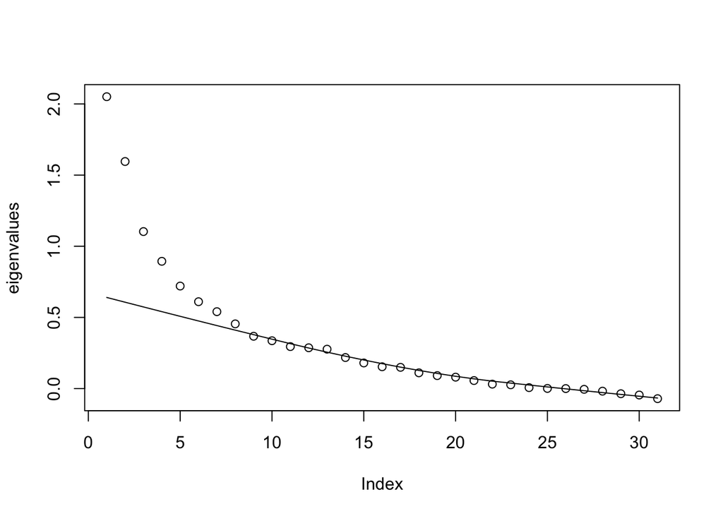

```r
# Scree plot:
  plot(eigenvalues)
  lines(lowess(eigenvalues))
```

```r
species_pc <- wascores(summer_pcoa$points[, 1:3], summer_plants_wis)
```

There seems to be an inflection point in the scree plot around axis 3.

Moving forward, keeping the first 3 axes as predictor variables for the rodent community.

### Winter PCoA

```r
winter_plants <- all_plants %>%
  filter(season == 'winter', treatment == 'control') %>%
  select(-season, -treatment)


winter_plants <- winter_plants[ , which(colSums(winter_plants) > 0)]


winter_plants_wis <- vegan::wisconsin(winter_plants[,2:ncol(winter_plants)])


winter_dist_mat <- vegdist(winter_plants_wis, 'bray')

winter_pcoa <- cmdscale(winter_dist_mat, k = nrow(winter_plants_wis) - 1, eig = T)
# Proportion of variance table
  eigenvalues <- winter_pcoa$eig[1:nrow(winter_plants_wis)-1]
  propVar <- eigenvalues/sum(eigenvalues)
  cumVar <- cumsum(propVar)
  winter_PCoA_Table <- cbind(eigenvalues, propVar, cumVar)

  winter_PCoA_Table[1:15,]
```

```
##       eigenvalues    propVar    cumVar
##  [1,]   2.4791232 0.22814312 0.2281431
##  [2,]   1.2204905 0.11231653 0.3404597
##  [3,]   1.1211349 0.10317326 0.4436329
##  [4,]   0.9427954 0.08676144 0.5303944
##  [5,]   0.6974427 0.06418268 0.5945770
##  [6,]   0.6037170 0.05555750 0.6501345
##  [7,]   0.5479375 0.05042435 0.7005589
##  [8,]   0.4965611 0.04569640 0.7462553
##  [9,]   0.4060608 0.03736804 0.7836233
## [10,]   0.3751394 0.03452248 0.8181458
## [11,]   0.3636433 0.03346454 0.8516103
## [12,]   0.3331781 0.03066095 0.8822713
## [13,]   0.2674315 0.02461058 0.9068819
## [14,]   0.2230801 0.02052911 0.9274110
## [15,]   0.1818489 0.01673478 0.9441458
```

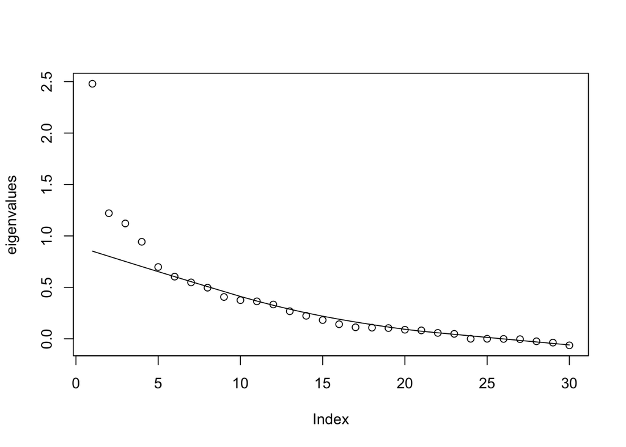

```r
# Scree plot:
  plot(eigenvalues)
  lines(lowess(eigenvalues))
```

```r
species_pc <- wascores(winter_pcoa$points[, 1:3], winter_plants_wis)
```

There seems to be an inflection point in the scree plot around axis 2 or 3. Since stopping at 2 would only capture 35% of variation, going to go for 3.

### Explore the PCoA axes

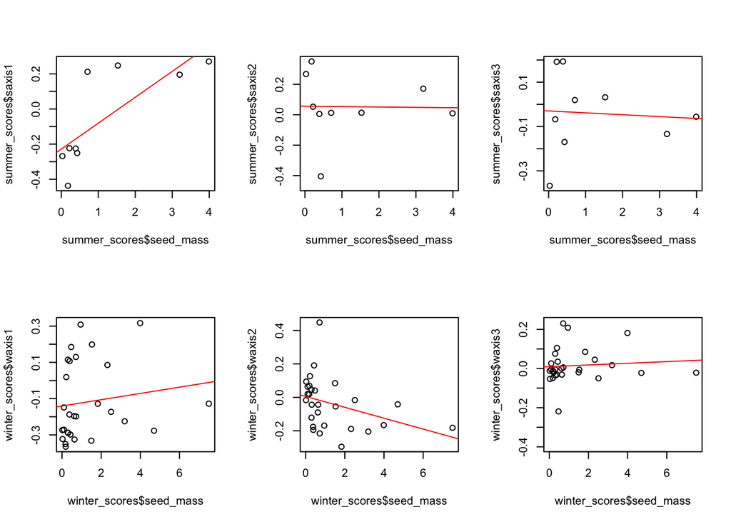

```r
summer_axes <- read.csv('models/summer_pcoa_axes.csv', stringsAsFactors = F)
winter_axes <- read.csv('models/winter_pcoa_axes.csv', stringsAsFactors = F)
summer_scores <- read.csv('models/summer_species_scores.csv',
                          stringsAsFactors = F)
winter_scores <- read.csv('models/winter_species_scores.csv',
                          stringsAsFactors = F)

colnames(winter_scores) <- c('speciescode', 'waxis1',
                             'waxis2', 'waxis3')
colnames(summer_scores) <- c('speciescode', 'saxis1',
                             'saxis2', 'saxis3')

# Compile species info & load
#
# source('R/compile_species_info.R')
# compile_species_info()

plant_info <- read.csv('data/compiled_plant_species_data.csv', stringsAsFactors = F)

plant_info <- select(plant_info, speciescode, community, seed_mass)

winter_scores <- left_join(winter_scores, plant_info, by = 'speciescode')

summer_scores <- left_join(summer_scores, plant_info, by = 'speciescode')

## Does seed mass predict scores

par(mfrow = c(2, 3))
plot(summer_scores$seed_mass, summer_scores$saxis1)
abline(lm(summer_scores$saxis1~summer_scores$seed_mass), col="red")
plot(summer_scores$seed_mass, summer_scores$saxis2)
abline(lm(summer_scores$saxis2~summer_scores$seed_mass), col="red")
plot(summer_scores$seed_mass, summer_scores$saxis3)
abline(lm(summer_scores$saxis3~summer_scores$seed_mass), col="red")

plot(winter_scores$seed_mass, winter_scores$waxis1)
abline(lm(winter_scores$waxis1~winter_scores$seed_mass), col="red")
plot(winter_scores$seed_mass, winter_scores$waxis2)
abline(lm(winter_scores$waxis2~winter_scores$seed_mass), col="red")
plot(winter_scores$seed_mass, winter_scores$waxis3)
abline(lm(winter_scores$waxis3~winter_scores$seed_mass), col="red")
```

```r
source('R/get_seed_mass_regression.R')

for(i in 1:3) {
this_regression <- get_seed_mass_regression(summer_scores, i + 1)
  print(this_regression)
}
```

```
## [[1]]
##               Estimate Std. Error   t value   Pr(>|t|)
## (Intercept) -0.2283479 0.08412710 -2.714321 0.03001095
## sizes        0.1475585 0.04652729  3.171439 0.01567639
##
## [[2]]
## [1] 0.589636
##
## [[1]]
##                 Estimate Std. Error     t value  Pr(>|t|)
## (Intercept)  0.056116718 0.10096078  0.55582692 0.5956395
## sizes       -0.002467633 0.05583732 -0.04419326 0.9659846
##
## [[2]]
## [1] 0.0002789285
##
## [[1]]
##                Estimate Std. Error    t value  Pr(>|t|)
## (Intercept) -0.02956449 0.08338998 -0.3545329 0.7333798
## sizes       -0.00855181 0.04611962 -0.1854267 0.8581528
##
## [[2]]
## [1] 0.004887859
```

```r
for(i in 1:3) {
this_regression <- get_seed_mass_regression(winter_scores, i + 1)
  print(this_regression)
}
```

```
## [[1]]
##                Estimate Std. Error    t value   Pr(>|t|)
## (Intercept) -0.14073641 0.05108763 -2.7548039 0.01057994
## sizes        0.01733563 0.02389797  0.7254016 0.47468470
##
## [[2]]
## [1] 0.01983727
##
## [[1]]
##                 Estimate Std. Error    t value  Pr(>|t|)
## (Intercept)  0.005564953 0.03481980  0.1598215 0.8742568
## sizes       -0.032540222 0.01628814 -1.9977858 0.0563022
##
## [[2]]
## [1] 0.1330775
##
## [[1]]
##                Estimate  Std. Error   t value  Pr(>|t|)
## (Intercept) 0.009619717 0.021344110 0.4506966 0.6559444
## sizes       0.004272651 0.009984431 0.4279313 0.6722250
##
## [[2]]
## [1] 0.006994016
```

```r
# Seed size predicts the score for summer axis 1, but not the other axes.

par(mfrow = c(1,1))

## Ordiplots

ordiplot(summer_scores[, c(2, 3)], type = "n", cex = 1, main = "Summer plant PCoA")
```

```
## species scores not available
```

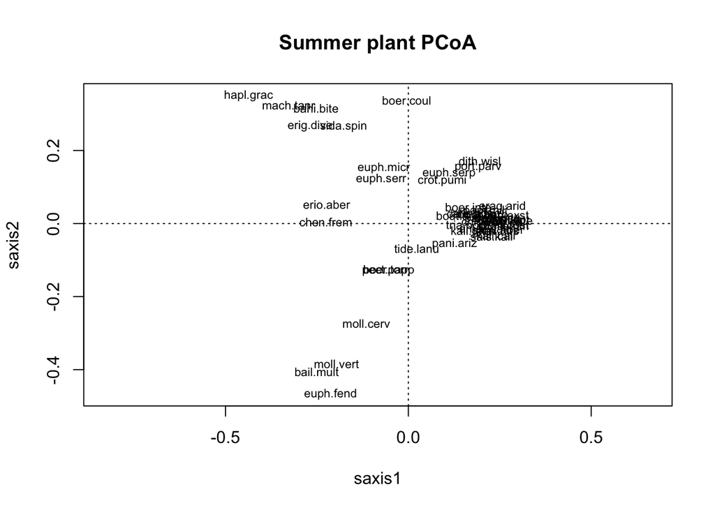

```r
abline(h = 0, lty = 3)
abline(v = 0, lty = 3)

# Add species

 text(summer_scores[, c(2, 3)], summer_scores$speciescode, cex = 0.7)
```

```r
ordiplot(winter_scores[, c(2, 3)], type = "n", cex = 1, main = "Winter plant PCoA")
```

```
## species scores not available
```

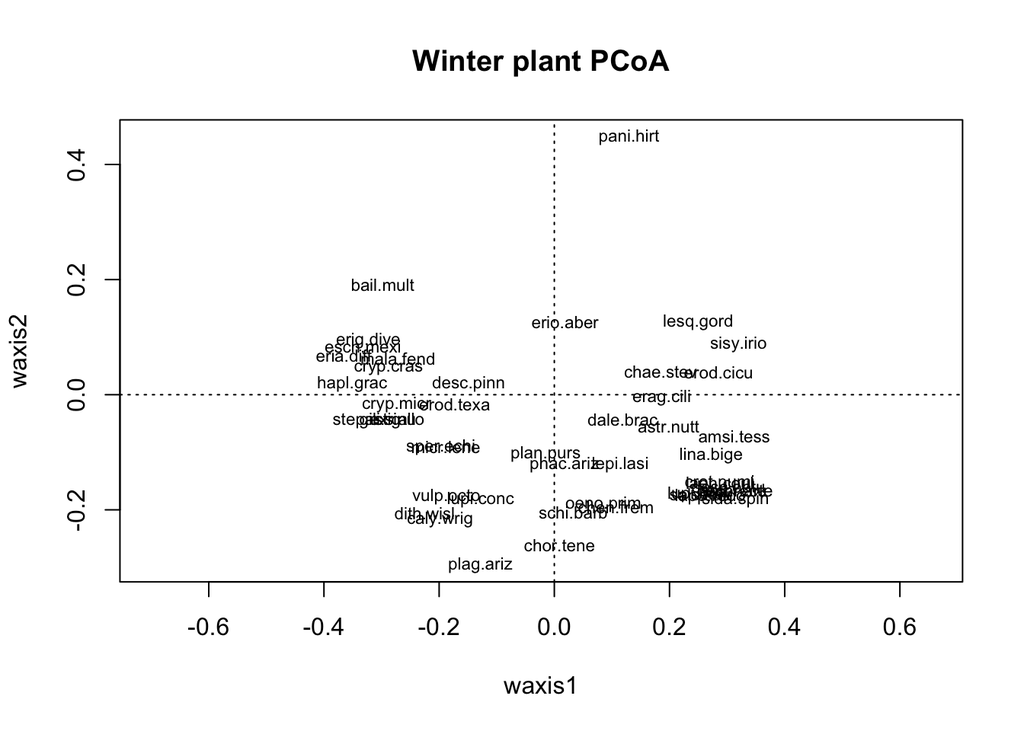

```r
abline(h = 0, lty = 3)
abline(v = 0, lty = 3)

# Add species

 text(winter_scores[, c(2, 3)], winter_scores$speciescode, cex = 0.7)
```

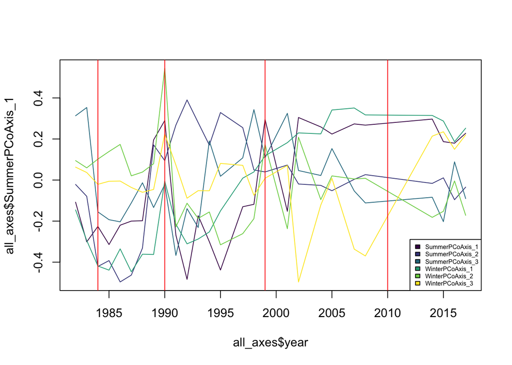

```r
 ### Axes through time

all_axes <- inner_join(summer_axes, winter_axes, by = 'year')

axismin = min(all_axes[,2:7])
axismax = max(all_axes[,2:7])

axis_cols <- viridis::viridis(6)
cpt_years <- c(1984, 1990, 1999, 2010)
plot(all_axes$year, all_axes$SummerPCoAxis_1, type ='n', ylim = c(axismin, axismax))
for(i in 1:6) {
  lines(all_axes$year, all_axes[,i+1], col = axis_cols[i])
}
for(i in 1:4) {
  abline(v = cpt_years[i], col = 'red')
}
legend(x = 'bottomright', legend = colnames(all_axes)[2:7],fill = axis_cols,
        cex = 0.5)
```

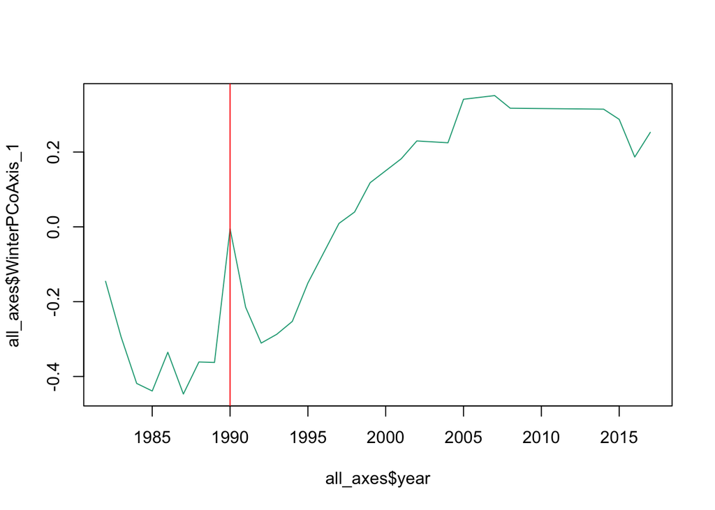

```r
plot(all_axes$year, all_axes$WinterPCoAxis_1, type = 'l', col = axis_cols[4])
abline(v = cpt_years[2], col = 'red')
```

```r
rm(list=ls())
```